# Formative Assessment 6: Discrimination and Classification (LDA and QDA)

## APM1220 - APPLIED MULTIVARIATE DATA ANALYSIS

Joseph Raphael Espiritu  
Spike Patayon

### Seed Dataset

The examined group comprised kernels belonging to three different varieties of wheat: Kama, Rosa and Canadian, 70 elements each, randomly selected for the experiment. High quality visualization of the internal kernel structure was detected using a soft X-ray technique. It is non-destructive and considerably cheaper than other more sophisticated imaging techniques like scanning microscopy or laser technology. The images were recorded on 13x18 cm X-ray KODAK plates. Studies were conducted using combine harvested wheat grain originating from experimental fields, explored at the Institute of Agrophysics of the Polish Academy of Sciences in Lublin.

Charytanowicz, M., Niewczas, J., Kulczycki, P., Kowalski, P., & Lukasik, S. (2010). Seeds [Dataset]. UCI Machine Learning Repository. https://doi.org/10.24432/C5H30K.

```python
import pandas as pd
import numpy as np
import matplotlib.pyplot as plt
import seaborn as sns
import pingouin as pg
from scipy.stats import chi2
from sklearn.model_selection import train_test_split
from sklearn.discriminant_analysis import LinearDiscriminantAnalysis
from sklearn.discriminant_analysis import QuadraticDiscriminantAnalysis
from sklearn.metrics import accuracy_score, confusion_matrix
from sklearn.metrics import classification_report
```

1. Data Exploration and Preparation (5 points)
   - Import the Seeds Dataset and identify its variables.
   - Identify Wheat Variety as the categorical response variable and the seven geometrical measurements as numerical predictors.
   - Present descriptive statistics for the seven numerical variables.
   - Examine the distribution of observations across the three wheat varieties.
   - Check for missing values and potential outliers.

```python
columns = [
    'area',
    'perimeter',
    'compactness',
    'length_kernel',
    'width_kernel',
    'asymmetry',
    ' length_kernel_groove',
    'wheat_variety'
]

df = pd.read_csv(
    "/content/seeds_dataset.txt",
    sep=r"\s+",
    header=None,
    names=columns
)

# Using standard print or displaying plain string to bypass the Colab interactive formatter bug
print(df.head().to_string())
```

```
    area  perimeter  compactness  length_kernel  width_kernel  asymmetry   length_kernel_groove  wheat_variety
0  15.26      14.84       0.8710          5.763         3.312      2.221                  5.220              1
1  14.88      14.57       0.8811          5.554         3.333      1.018                  4.956              1
2  14.29      14.09       0.9050          5.291         3.337      2.699                  4.825              1
3  13.84      13.94       0.8955          5.324         3.379      2.259                  4.805              1
4  16.14      14.99       0.9034          5.658         3.562      1.355                  5.175              1
```

```python
print('Dataset Dimension: ', df.shape)
print('\n')
print(df.info)
```

[output not shown]

| Variable | Description | Data type |
| --- | --- | --- |
| `area` | Area of the wheat kernel | Continuous |
| `perimeter` | Perimeter of the wheat kernel | Continuous |
| `compactness` | Degree of compactness of the kernel | Continuous |
| `length` | Length of the kernel | Continuous |
| `width` | Width of the kernel | Continuous |
| `asymmetry` | Asymmetry coefficient | Continuous |
| `length of kernel groove` | Length of the kernel groove | Continuous |
| `wheat_variety` | Variety of wheat | Categorical |

Identify the response variable and numerical predictors Response variable (Y):

- Wheat Variety

Numerical predictor variables (X):

- Area
- Perimeter
- Compactness
- Length of kernel
- Width of kernel
- Asymmetry coefficient
- Length of kernel groove

Since wheat variety is represented numerically in the original dataset, we can convert the labels into their corresponding wheat variety names.

```python
df['wheat_variety'] = df['wheat_variety'].map({
    1: 'Kama',
    2: 'Rosa',
    3: 'Canadian'
})
# Use print(df.to_string()) to bypass the Colab interactive table formatter bug
print(df.head().to_string())
```

```
    area  perimeter  compactness  length_kernel  width_kernel  asymmetry   length_kernel_groove wheat_variety
0  15.26      14.84       0.8710          5.763         3.312      2.221                  5.220          Kama
1  14.88      14.57       0.8811          5.554         3.333      1.018                  4.956          Kama
2  14.29      14.09       0.9050          5.291         3.337      2.699                  4.825          Kama
3  13.84      13.94       0.8955          5.324         3.379      2.259                  4.805          Kama
4  16.14      14.99       0.9034          5.658         3.562      1.355                  5.175          Kama
```

We can also separate the predictors and response variable for subsequent statistical analysis:

```python
X = df.drop(columns=['wheat_variety'])
y = df['wheat_variety']
```

The response variable is Wheat Variety, a nominal categorical variable consisting of three classes: Kama, Rosa, and Canadian. The seven geometric measurements serve as continuous numerical predictors that can be used to distinguish and classify the different wheat varieties.

```python
X.describe().T.round(4)
```

|  | count | mean | std | min | 25% | 50% | 75% | max |
| --- | --- | --- | --- | --- | --- | --- | --- | --- |
| area | 210.0 | 14.8475 | 2.9097 | 10.5900 | 12.2700 | 14.3550 | 17.3050 | 21.1800 |
| perimeter | 210.0 | 14.5593 | 1.3060 | 12.4100 | 13.4500 | 14.3200 | 15.7150 | 17.2500 |
| compactness | 210.0 | 0.8710 | 0.0236 | 0.8081 | 0.8569 | 0.8734 | 0.8878 | 0.9183 |
| length_kernel | 210.0 | 5.6285 | 0.4431 | 4.8990 | 5.2622 | 5.5235 | 5.9798 | 6.6750 |
| width_kernel | 210.0 | 3.2586 | 0.3777 | 2.6300 | 2.9440 | 3.2370 | 3.5618 | 4.0330 |
| asymmetry | 210.0 | 3.7002 | 1.5036 | 0.7651 | 2.5615 | 3.5990 | 4.7688 | 8.4560 |
| length_kernel_groove | 210.0 | 5.4081 | 0.4915 | 4.5190 | 5.0450 | 5.2230 | 5.8770 | 6.5500 |

The descriptive statistics show that all seven numerical variables contain 210 observations. Area has a mean of 14.8475, while perimeter has a mean of 14.5593. Compactness has relatively little variation, with a standard deviation of 0.0236. Meanwhile, the asymmetry coefficient exhibits considerable variation relative to its mean. The differences in measurement scales suggest that standardization may be necessary for subsequent statistical and classification methods that are sensitive to variable scales.

For additional visualization

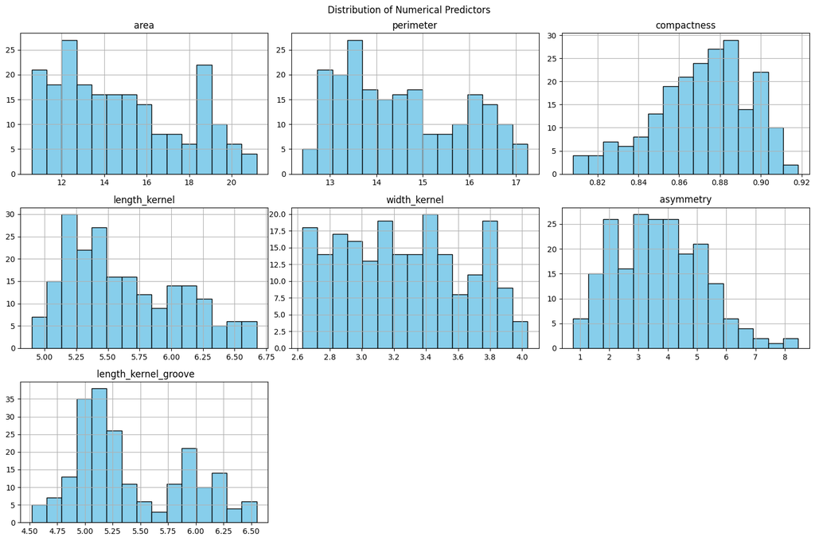

```python
X.hist(
    bins=15,
    figsize=(15, 10),
    edgecolor="black",
    color="skyblue"
)

plt.suptitle("Distribution of Numerical Predictors")
plt.tight_layout()
plt.show()
```

Examine the distribution of observations across the three wheat varieties

```python
class_distribution = pd.DataFrame({
    "Frequency": y.value_counts(),
    "Percentage (%)": y.value_counts(normalize=True) * 100
})

class_distribution.round(2)
```

| wheat_variety | Frequency | Percentage (%) |
| --- | --- | --- |
| Kama | 70 | 33.33 |
| Rosa | 70 | 33.33 |
| Canadian | 70 | 33.33 |

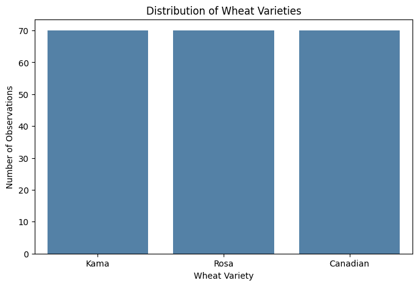

```python
plt.figure(figsize=(8, 5))

sns.countplot(
    data=df,
    x="wheat_variety",
    order=["Kama", "Rosa", "Canadian"],
    color="steelblue"
)

plt.title("Distribution of Wheat Varieties")
plt.xlabel("Wheat Variety")
plt.ylabel("Number of Observations")
plt.show()
```

The dataset contains an equal number of observations for each wheat variety, with 70 observations representing approximately 33.33% of the total dataset. This indicates that the dataset is perfectly balanced. Therefore, class imbalance is not a concern, and resampling techniques such as oversampling or undersampling are unnecessary for addressing class imbalance.

Check for missing values and potential outliers

```python
df.isnull().sum()
```

|  | 0 |
| --- | --- |
| area | 0 |
| perimeter | 0 |
| compactness | 0 |
| length_kernel | 0 |
| width_kernel | 0 |
| asymmetry | 0 |
| length_kernel_groove | 0 |
| wheat_variety | 0 |

**dtype:** int64

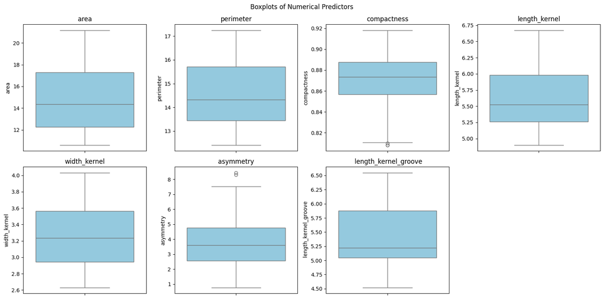

```python
fig, axes = plt.subplots(2, 4, figsize=(16, 8))

axes = axes.flatten()

for i, column in enumerate(X.columns):
    sns.boxplot(y=X[column], ax=axes[i], color="skyblue")
    axes[i].set_title(column)

fig.delaxes(axes[7])

plt.suptitle("Boxplots of Numerical Predictors")
plt.tight_layout()
plt.show()
```

By examining the boxplot, we can see some potential outliers

The IQR method

```python
Q1 = X.quantile(0.25)
Q3 = X.quantile(0.75)

IQR = Q3 - Q1

lower_bound = Q1 - 1.5 * IQR
upper_bound = Q3 + 1.5 * IQR

outliers = (X < lower_bound) | (X > upper_bound)

outlier_summary = pd.DataFrame({
    "Q1": Q1,
    "Q3": Q3,
    "IQR": IQR,
    "Lower Bound": lower_bound,
    "Upper Bound": upper_bound,
    "Number of Outliers": outliers.sum()
})

outlier_summary.round(4)
```

|  | Q1 | Q3 | IQR | Lower Bound | Upper Bound | Number of Outliers |
| --- | --- | --- | --- | --- | --- | --- |
| area | 12.2700 | 17.3050 | 5.0350 | 4.7175 | 24.8575 | 0 |
| perimeter | 13.4500 | 15.7150 | 2.2650 | 10.0525 | 19.1125 | 0 |
| compactness | 0.8569 | 0.8878 | 0.0309 | 0.8106 | 0.9341 | 3 |
| length_kernel | 5.2622 | 5.9798 | 0.7175 | 4.1860 | 7.0560 | 0 |
| width_kernel | 2.9440 | 3.5618 | 0.6178 | 2.0174 | 4.4884 | 0 |
| asymmetry | 2.5615 | 4.7688 | 2.2072 | -0.7494 | 8.0796 | 2 |
| length_kernel_groove | 5.0450 | 5.8770 | 0.8320 | 3.7970 | 7.1250 | 0 |

```python
df[outliers.any(axis=1)]
```

|  | area | perimeter | compactness | length_kernel | width_kernel | asymmetry | length_kernel_groove | wheat_variety |
| --- | --- | --- | --- | --- | --- | --- | --- | --- |
| 157 | 12.13 | 13.73 | 0.8081 | 5.394 | 2.745 | 4.825 | 5.220 | Canadian |
| 158 | 11.75 | 13.52 | 0.8082 | 5.444 | 2.678 | 4.378 | 5.310 | Canadian |
| 174 | 10.83 | 12.96 | 0.8099 | 5.278 | 2.641 | 5.182 | 5.185 | Canadian |
| 203 | 12.70 | 13.41 | 0.8874 | 5.183 | 3.091 | 8.456 | 5.000 | Canadian |
| 207 | 13.20 | 13.66 | 0.8883 | 5.236 | 3.232 | 8.315 | 5.056 | Canadian |

```python
print("Total observations with potential outliers:",
      outliers.any(axis=1).sum())
```

```
Total observations with potential outliers: 5
```

Using the IQR method, five observations were identified as potential outliers, consisting of three observations in compactness and two observations in the asymmetry coefficient. The remaining five numerical variables contain no potential outliers under this method.

However, these observations may represent natural variations in the geometric characteristics of wheat kernels rather than measurement errors. Therefore, the potential outliers should be retained unless further investigation provides sufficient evidence to justify their removal.

2. Exploratory Analysis and Assumption Checking (7 points)
   - Generate appropriate graphical representations, including scatterplots and distribution plots.
   - Examine the multivariate normality assumption within each wheat variety.
   - Perform Box's M-test to examine the equality of covariance matrices.
   - Formulate the appropriate null and alternative hypotheses.
   - Interpret the diagnostic results and explain their implications for choosing between LDA and QDA.

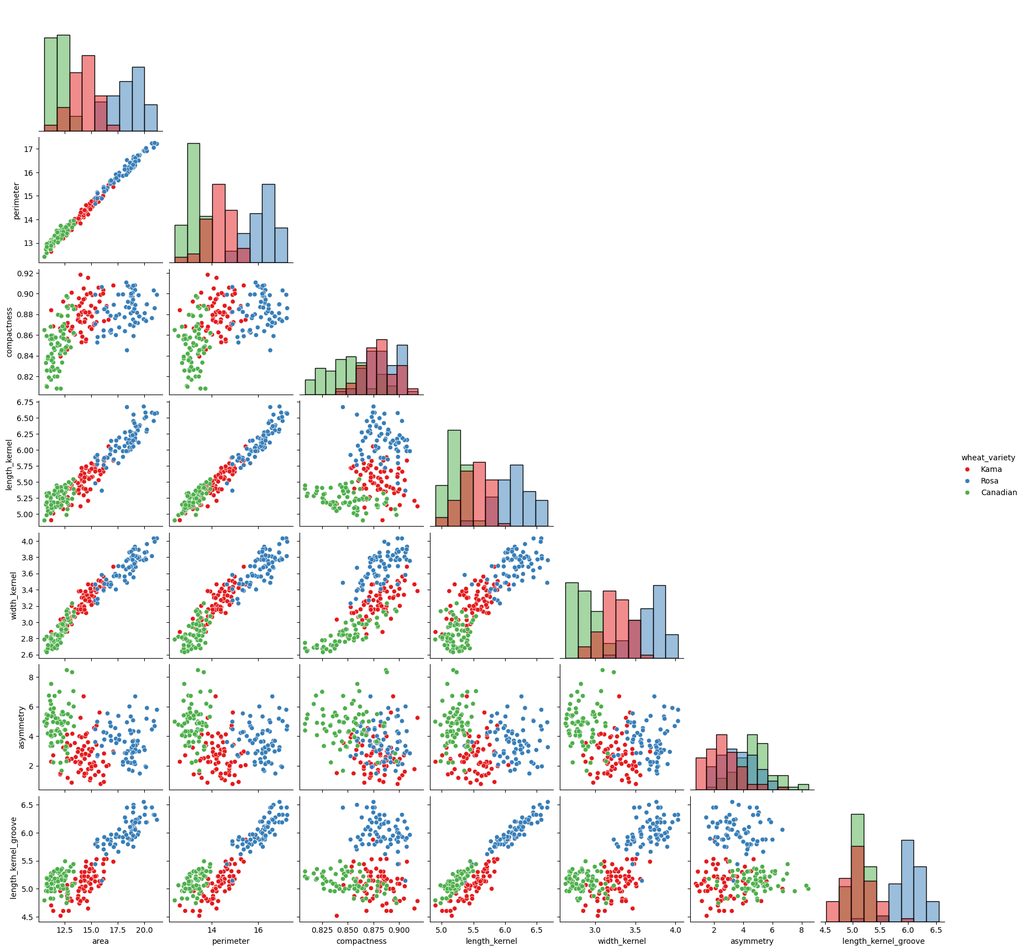

```python
sns.pairplot(
    df,
    hue="wheat_variety",
    diag_kind="hist",
    palette="Set1",
    corner=True
)

plt.show()
```

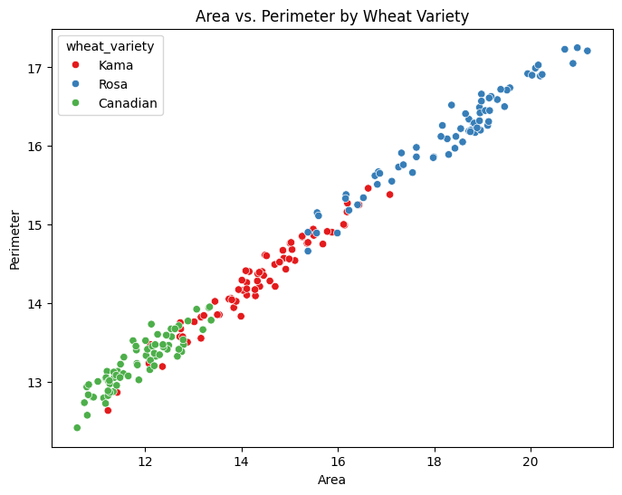

```python
plt.figure(figsize=(8, 6))

sns.scatterplot(
    data=df,
    x="area",
    y="perimeter",
    hue="wheat_variety",
    palette="Set1"
)

plt.title("Area vs. Perimeter by Wheat Variety")
plt.xlabel("Area")
plt.ylabel("Perimeter")
plt.show()
```

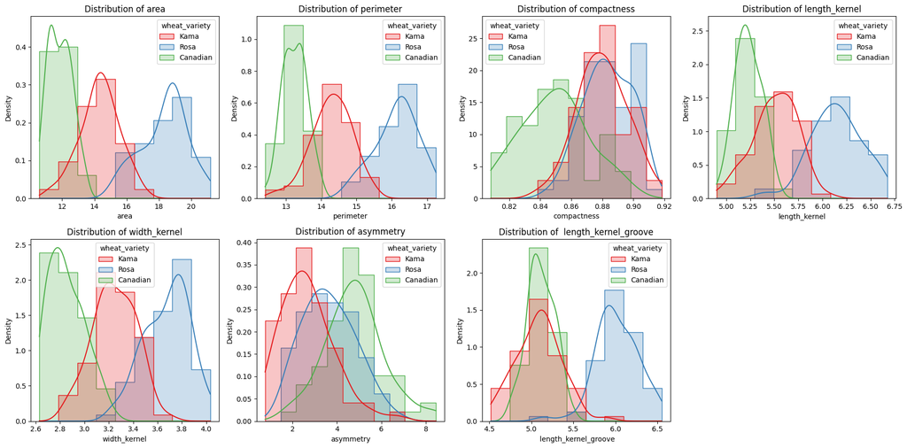

```python
fig, axes = plt.subplots(2, 4, figsize=(18, 9))
axes = axes.flatten()

for i, column in enumerate(X.columns):
    sns.histplot(
        data=df,
        x=column,
        hue="wheat_variety",
        kde=True,
        element="step",
        stat="density",
        common_norm=False,
        palette="Set1",
        ax=axes[i]
    )

    axes[i].set_title(f"Distribution of {column}")

fig.delaxes(axes[7])

plt.tight_layout()
plt.show()
```

Examine the multivariate normality assumption

**Null Hypothesis ($H_0$):**

The seven numerical predictors follow a multivariate normal distribution within the given wheat variety.

$$H_0: \mathbf{X}_k \sim N_7(\boldsymbol{\mu}_k, \boldsymbol{\Sigma}_k)$$

**Alternative Hypothesis ($H_1$):**

The seven numerical predictors do not follow a multivariate normal distribution within the given wheat variety.

**Where:**

- $k$ represents the wheat variety.
- $\boldsymbol{\mu}_k$ is the mean vector of variety $k$.
- $\boldsymbol{\Sigma}_k$ is the covariance matrix of variety $k$.

**Decision Rule at $\alpha = 0.05$:**

| Condition | Statistical Decision |
| --- | --- |
| $p \leq 0.05$ | Reject the null hypothesis |
| $p > 0.05$ | Fail to reject the null hypothesis |

```python
normality_results = []

for variety in ["Kama", "Rosa", "Canadian"]:

    group_data = df.loc[
        df["wheat_variety"] == variety,
        X.columns
    ]

    hz, pval, normal = pg.multivariate_normality(
        group_data,
        alpha=0.05
    )

    normality_results.append({
        "Wheat Variety": variety,
        "HZ Statistic": hz,
        "p-value": pval,
        "Normal": normal,
        "Decision": "Fail to Reject H0" if normal
                    else "Reject H0"
    })

normality_results = pd.DataFrame(normality_results)

normality_results
```

|  | Wheat Variety | HZ Statistic | p-value | Normal | Decision |
| --- | --- | --- | --- | --- | --- |
| 0 | Kama | 1.255606 | 1.982060e-14 | False | Reject H0 |
| 1 | Rosa | 1.150907 | 2.940114e-08 | False | Reject H0 |
| 2 | Canadian | 0.963675 | 1.448198e-01 | True | Fail to Reject H0 |

The Henze–Zirkler test results indicate that Kama and Rosa have p-values below the significance level of 0.05. Therefore, the null hypothesis of multivariate normality is rejected for these two wheat varieties.

In contrast, Canadian has a p-value of 0.1448, which is greater than 0.05. Consequently, there is insufficient evidence to reject multivariate normality for this variety.

Overall, the multivariate normality assumption is not fully satisfied because two of the three wheat varieties exhibit statistically significant departures from multivariate normality.

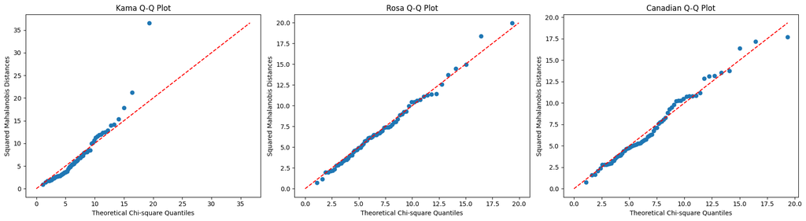

```python
fig, axes = plt.subplots(1, 3, figsize=(18, 5))

for ax, variety in zip(
    axes, ["Kama", "Rosa", "Canadian"]
):

    group = df.loc[
        df["wheat_variety"] == variety,
        X.columns
    ].to_numpy()

    n, p = group.shape

    mean = group.mean(axis=0)
    covariance = np.cov(group, rowvar=False)
    inverse_covariance = np.linalg.pinv(covariance)

    centered = group - mean

    mahalanobis_squared = np.einsum(
        "ij,jk,ik->i",
        centered,
        inverse_covariance,
        centered
    )

    observed = np.sort(mahalanobis_squared)

    theoretical = chi2.ppf(
        (np.arange(1, n + 1) - 0.5) / n,
        df=p
    )

    ax.scatter(theoretical, observed)

    limit = max(theoretical.max(), observed.max())

    ax.plot(
        [0, limit],
        [0, limit],
        "r--"
    )

    ax.set_title(f"{variety} Q-Q Plot")
    ax.set_xlabel("Theoretical Chi-square Quantiles")
    ax.set_ylabel("Squared Mahalanobis Distances")

plt.tight_layout()
plt.show()
```

Perform Box's M-test for equality of covariance matrices

Box's M-test determines whether the covariance matrices of the numerical predictors are equal across the three wheat varieties. This assumption is particularly important because:

- **LDA** assumes that all classes share a common covariance matrix.
- **QDA** allows each class to have its own covariance matrix.

Formulate the Hypotheses

**Null Hypothesis ($H_0$):**

The covariance matrices of the three wheat varieties are equal.

$$H_0: \boldsymbol{\Sigma}_{\text{Kama}} = \boldsymbol{\Sigma}_{\text{Rosa}} = \boldsymbol{\Sigma}_{\text{Canadian}}$$

**Alternative Hypothesis ($H_1$):**

At least one covariance matrix differs from the others.

$$H_1: \boldsymbol{\Sigma}_i \neq \boldsymbol{\Sigma}_j \quad \text{for some } i \neq j$$

**Decision Rule at $\alpha = 0.05$:**

| Condition | Decision | Interpretation |
| --- | --- | --- |
| $p \leq 0.05$ | Reject $H_0$ | Unequal covariance matrices |
| $p > 0.05$ | Fail to reject $H_0$ | Insufficient evidence of unequal covariance matrices |

```python
box_m_result = pg.box_m(
    data=df,
    dvs=X.columns.tolist(),
    group="wheat_variety",
    alpha=0.05
)

box_m_result
```

|  | Chi2 | df | pval | equal_cov |
| --- | --- | --- | --- | --- |
| box | 674.11733 | 56.0 | 7.319608e-107 | False |

Box's M-test produced a corrected chi-square statistic of 674.1173 with 56 degrees of freedom and a p-value of approximately $7.3196\times10^{-107}$.

Since the p-value is significantly lower than the significance level of 0.05, the null hypothesis is rejected. This provides statistical evidence that the covariance matrices of the three wheat varieties differ.

However, Box's M-test is sensitive to departures from multivariate normality. Since the earlier Henze–Zirkler test identified violations of multivariate normality in Kama and Rosa, the results should be interpreted with caution.

Even when using the more conservative significance level of 0.001, the conclusion remains unchanged.

Implications for choosing between LDA and QDA

For context, these are the characteristics of LDA and QDA for better understanding:

| Characteristics | LDA | QDA |
| --- | --- | --- |
| Multivariate normality required by model | Yes | Yes |
| Equal covariance matrices | Required | Not required |
| Covariance estimation | Pooled covariance matrix | Separate covariance matrices |
| Decision boundary | Linear | Quadratic |
| Model complexity | Lower | Higher |
| Risk of overfitting | Generally lower | Generally higher |
| Flexibility | Lower | Higher |
| Alignment with Box's M-test results | Less suitable | More suitable |

Based on these findings,**Quadratic Discriminant Analysis (QDA)** is considered more appropriate in terms of accommodating unequal covariance matrices. However, because both LDA and QDA assume multivariate normality, neither model completely satisfies its theoretical assumptions. Therefore, both classification models should be implemented and evaluated based on their predictive performance to determine the most suitable approach for classifying wheat varieties.

The Henze–Zirkler multivariate normality test was performed to determine whether the seven numerical predictors jointly followed a multivariate normal distribution within each wheat variety. The results revealed statistically significant departures from multivariate normality for Kama and Rosa, with p-values below the 0.05 significance level. Meanwhile, Canadian obtained a p-value of 0.1448, indicating insufficient evidence to reject the null hypothesis of multivariate normality. Therefore, the multivariate normality assumption was not fully satisfied.

Furthermore, Box's M-test was conducted to examine the equality of covariance matrices across the three wheat varieties. The test yielded a corrected chi-square statistic of 674.1173 with 56 degrees of freedom and a p-value significantly below 0.05. Consequently, the null hypothesis was rejected, providing evidence that the covariance matrices differ across the three wheat varieties. Nevertheless, this result should be interpreted cautiously due to the observed departures from multivariate normality.

3. Model Development: LDA and QDA (10 points)
   - Partition the dataset into training (70%) and testing (30%) sets using stratified random sampling to preserve the class proportions.
   - Use the same partition for both classification models.
   - Fit an LDA model using the training dataset.
   - Fit a QDA model using the same training dataset.
   - Obtain predicted class memberships and posterior probabilities.
   - Present and interpret the classification results.

**Important note:** Based on the previous assumption checking, **QDA** was identified as the preliminary preferred model because it accommodates unequal covariance matrices. However, we need to develop both models using the same training and testing datasets to ensure a fair comparison.

Partition the dataset using stratified random sampling The dataset will be divided into:

- Training set (70%): Used to train the LDA and QDA models.
- Testing set (30%): Used to evaluate the classification performance on unseen observations.

```python
X = df.drop(columns=["wheat_variety"])
y = df["wheat_variety"]

X_train, X_test, y_train, y_test = train_test_split(
    X,
    y,
    test_size=0.30,
    random_state=42,
    stratify=y
)

print("Training set:", X_train.shape)
print("Testing set:", X_test.shape)
```

```
Training set: (147, 7)
Testing set: (63, 7)
```

Verify Class distribution

```python
partition_summary = pd.DataFrame({
    "Original Dataset": y.value_counts(),
    "Training Set": y_train.value_counts(),
    "Testing Set": y_test.value_counts()
})

partition_summary
```

| wheat_variety | Original Dataset | Training Set | Testing Set |
| --- | --- | --- | --- |
| Canadian | 70 | 49 | 21 |
| Kama | 70 | 49 | 21 |
| Rosa | 70 | 49 | 21 |

Fit the Linear Discriminant Analysis (LDA) Model

Linear Discriminant Analysis estimates a common pooled covariance matrix for the three wheat varieties. It then uses the estimated class means, common covariance structure, and class prior probabilities to classify observations.

The LDA model is fitted using only the training data. The testing data are kept separate for the prediction stage.

```python
lda_model = LinearDiscriminantAnalysis()
lda_model.fit(X_train, y_train)

print("LDA model fitted successfully.")
print("Class labels:", lda_model.classes_)
print("Estimated class priors:")
display(pd.Series(lda_model.priors_, index=lda_model.classes_, name="LDA Prior Probability"))
```

```
LDA model fitted successfully.
Class labels: ['Canadian' 'Kama' 'Rosa']
Estimated class priors:
```

|  | LDA Prior Probability |
| --- | --- |
| Canadian | 0.333333 |
| Kama | 0.333333 |
| Rosa | 0.333333 |

**dtype:** float64

Fit the Quadratic Discriminant Analysis (QDA) Model

Quadratic Discriminant Analysis estimates a separate covariance matrix for each wheat variety. This allows the model to represent class-specific covariance structures and produce quadratic rather than strictly linear decision boundaries.

Numerical consideration: With the fixed stratified partition (random_state=42), unregularized QDA reports that the estimated covariance matrix for the Canadian class is not full rank. To make the covariance estimates numerically stable, a small regularization value of 0.0001 is applied. This does not add or remove observations or predictors. It is a numerical stabilization adjustment and should be reported as part of the model specification.

```python
qda_model = QuadraticDiscriminantAnalysis(reg_param=0.0001)
qda_model.fit(X_train, y_train)

print("QDA model fitted successfully with reg_param=0.0001.")
print("Class labels:", qda_model.classes_)
print("Estimated class priors:")
display(pd.Series(qda_model.priors_, index=qda_model.classes_, name="QDA Prior Probability"))
```

```
QDA model fitted successfully with reg_param=0.0001.
Class labels: ['Canadian' 'Kama' 'Rosa']
Estimated class priors:
```

|  | QDA Prior Probability |
| --- | --- |
| Canadian | 0.333333 |
| Kama | 0.333333 |
| Rosa | 0.333333 |

**dtype:** float64

Obtain Predicted Class Memberships

After fitting both classifiers, use each model to predict the wheat variety of the observations in the testing set. The two prediction vectors correspond to the exact same 63 testing observations

```python
lda_predictions = lda_model.predict(X_test)
qda_predictions = qda_model.predict(X_test)

prediction_membership = pd.DataFrame(
    {
        "Actual Variety": y_test,
        "LDA Predicted Variety": pd.Series(lda_predictions, index=X_test.index),
        "QDA Predicted Variety": pd.Series(qda_predictions, index=X_test.index)
    },
    index=X_test.index
).sort_index()

display(prediction_membership)
```

|  | Actual Variety | LDA Predicted Variety | QDA Predicted Variety |
| --- | --- | --- | --- |
| 0 | Kama | Kama | Kama |
| 6 | Kama | Kama | Kama |
| 8 | Kama | Rosa | Rosa |
| 14 | Kama | Kama | Kama |
| 23 | Kama | Canadian | Canadian |
| ... | ... | ... | ... |
| 200 | Canadian | Canadian | Canadian |
| 201 | Canadian | Kama | Kama |
| 203 | Canadian | Canadian | Canadian |
| 205 | Canadian | Canadian | Canadian |
| 206 | Canadian | Canadian | Canadian |

63 rows × 3 columns

Obtain Posterior Probabilities

Posterior probabilities represent the probability assigned by a fitted classifier to each possible wheat variety, conditional on the observed kernel measurements.

For every testing observation, the three class probabilities sum to 1. The predicted class is the variety with the highest posterior probability.

The posterior probabilities are useful for examining how strongly each model supports its predicted class. A high posterior probability indicates stronger model-assigned support, but it does not guarantee that the prediction is correct.

```python
# Obtain posterior probabilities for each class from both fitted models.
lda_posterior = pd.DataFrame(
    lda_model.predict_proba(X_test),
    columns=[f"LDA P({class_name})" for class_name in lda_model.classes_],
    index=X_test.index
)

qda_posterior = pd.DataFrame(
    qda_model.predict_proba(X_test),
    columns=[f"QDA P({class_name})" for class_name in qda_model.classes_],
    index=X_test.index
)

# Combine actual labels, predicted labels, and posterior probabilities.
classification_results = pd.concat(
    [
        prediction_membership,
        lda_posterior,
        qda_posterior
    ],
    axis=1
).sort_index()

display(classification_results.round(4))
```

|  | Actual Variety | LDA Predicted Variety | QDA Predicted Variety | LDA P(Canadian) | LDA P(Kama) | LDA P(Rosa) | QDA P(Canadian) | QDA P(Kama) | QDA P(Rosa) |
| --- | --- | --- | --- | --- | --- | --- | --- | --- | --- |
| 0 | Kama | Kama | Kama | 0.0000 | 1.0000 | 0.0000 | 0.0000 | 1.0000 | 0.0000 |
| 6 | Kama | Kama | Kama | 0.0001 | 0.9998 | 0.0001 | 0.0000 | 1.0000 | 0.0000 |
| 8 | Kama | Rosa | Rosa | 0.0000 | 0.0347 | 0.9653 | 0.0000 | 0.1198 | 0.8802 |
| 14 | Kama | Kama | Kama | 0.0000 | 1.0000 | 0.0000 | 0.0000 | 1.0000 | 0.0000 |
| 23 | Kama | Canadian | Canadian | 0.9872 | 0.0128 | 0.0000 | 0.9553 | 0.0447 | 0.0000 |
| ... | ... | ... | ... | ... | ... | ... | ... | ... | ... |
| 200 | Canadian | Canadian | Canadian | 0.9993 | 0.0007 | 0.0000 | 0.9990 | 0.0010 | 0.0000 |
| 201 | Canadian | Kama | Kama | 0.1000 | 0.9000 | 0.0000 | 0.0417 | 0.9583 | 0.0000 |
| 203 | Canadian | Canadian | Canadian | 0.9998 | 0.0002 | 0.0000 | 1.0000 | 0.0000 | 0.0000 |
| 205 | Canadian | Canadian | Canadian | 0.9390 | 0.0610 | 0.0000 | 0.9880 | 0.0120 | 0.0000 |
| 206 | Canadian | Canadian | Canadian | 1.0000 | 0.0000 | 0.0000 | 1.0000 | 0.0000 | 0.0000 |

63 rows × 9 columns

Summarize the Predicted Class Memberships

The table below compares the number of testing observations assigned to each variety by LDA and QDA. The actual testing set contains 21 observations per variety because stratification was used in the 70:30 partition.

```python
class_order = ["Kama", "Rosa", "Canadian"]

predicted_class_counts = pd.DataFrame(
    {
        "Actual Test Set": y_test.value_counts().reindex(class_order, fill_value=0),
        "LDA Predicted": pd.Series(lda_predictions).value_counts().reindex(class_order, fill_value=0),
        "QDA Predicted": pd.Series(qda_predictions).value_counts().reindex(class_order, fill_value=0)
    }
)

display(predicted_class_counts)
```

|  | Actual Test Set | LDA Predicted | QDA Predicted |
| --- | --- | --- | --- |
| Kama | 21 | 19 | 20 |
| Rosa | 21 | 22 | 22 |
| Canadian | 21 | 22 | 21 |

Summarize Posterior Probability Support

For each model, the maximum posterior probability is the largest of the three class probabilities for a given testing observation. This summary describes the degree of confidence assigned by each classifier to its predicted classes. It is not a substitute for the confusion matrix or accuracy measures in Part 4.

```python
posterior_support = pd.DataFrame(
    {
        "LDA Maximum Posterior": lda_posterior.max(axis=1),
        "QDA Maximum Posterior": qda_posterior.max(axis=1)
    }
)

posterior_support_summary = posterior_support.agg(
    ["mean", "median", "min", "max"]
).T

display(posterior_support_summary.round(4))
```

|  | mean | median | min | max |
| --- | --- | --- | --- | --- |
| LDA Maximum Posterior | 0.9851 | 1.0 | 0.5666 | 1.0 |
| QDA Maximum Posterior | 0.9793 | 1.0 | 0.5971 | 1.0 |

Initial Interpretation of the Classification Results

The LDA and QDA models were both developed using the same 147 training observations and evaluated for predicted class membership on the same 63 testing observations. This ensures that any differences in their predictions are not caused by using different training and testing partitions.

LDA uses a pooled covariance matrix, resulting in linear classification boundaries. QDA estimates separate covariance matrices for Kama, Rosa, and Canadian, allowing more flexible quadratic classification boundaries. The small regularization value used for QDA addresses the rank-deficiency issue encountered in the Canadian training-class covariance estimate.

The prediction table presents the actual wheat variety alongside the predicted variety from each model. The posterior-probability columns show the probability assigned to Kama, Rosa, and Canadian for each observation. These probabilities sum to approximately 1 within each model, subject to numerical rounding. The predicted membership is the class with the largest posterior probability.

The predicted class-count table provides an initial view of how the two models assign testing observations across the three varieties. However, these counts alone do not establish which classifier performs better. A prediction may be assigned to a class even when it is incorrect, and posterior probability describes model-assigned support rather than confirmed correctness.

Therefore, the final comparison of LDA and QDA will be conducted and the model with the higher validation performance should be preferred based on the actual results rather than the covariance assumption test alone.

Confusion Matrices

A confusion matrix compares the actual class membership with the predicted class membership. The rows represent the actual wheat varieties, while the columns represent the predicted varieties.

The class order is kept consistent for both models:

1. Kama
2. Rosa
3. Canadian

For a three-class classification problem, the diagonal entries represent correctly classified observations, while the off-diagonal entries represent misclassifications.

```python
from sklearn.metrics import confusion_matrix, ConfusionMatrixDisplay
from sklearn.model_selection import StratifiedKFold, cross_val_score

class_order = ["Kama", "Rosa", "Canadian"]

# Confirm that Part 3's fitted models and predictions are available.
assert "lda_model" in globals() and "qda_model" in globals()
assert "lda_predictions" in globals() and "qda_predictions" in globals()
assert len(y_test) == 63, "The expected testing set contains 63 observations."
assert len(lda_predictions) == len(y_test)
assert len(qda_predictions) == len(y_test)

# Construct both confusion matrices using the same actual test labels.
lda_cm = confusion_matrix(y_test, lda_predictions, labels=class_order)
qda_cm = confusion_matrix(y_test, qda_predictions, labels=class_order)

print("LDA Confusion Matrix")
display(pd.DataFrame(
    lda_cm,
    index=[f"Actual {c}" for c in class_order],
    columns=[f"Predicted {c}" for c in class_order]
))

print("QDA Confusion Matrix")
display(pd.DataFrame(
    qda_cm,
    index=[f"Actual {c}" for c in class_order],
    columns=[f"Predicted {c}" for c in class_order]
))
```

```
LDA Confusion Matrix
```

|  | Predicted Kama | Predicted Rosa | Predicted Canadian |
| --- | --- | --- | --- |
| Actual Kama | 17 | 1 | 3 |
| Actual Rosa | 0 | 21 | 0 |
| Actual Canadian | 2 | 0 | 19 |

```
QDA Confusion Matrix
```

|  | Predicted Kama | Predicted Rosa | Predicted Canadian |
| --- | --- | --- | --- |
| Actual Kama | 18 | 1 | 2 |
| Actual Rosa | 0 | 21 | 0 |
| Actual Canadian | 2 | 0 | 19 |

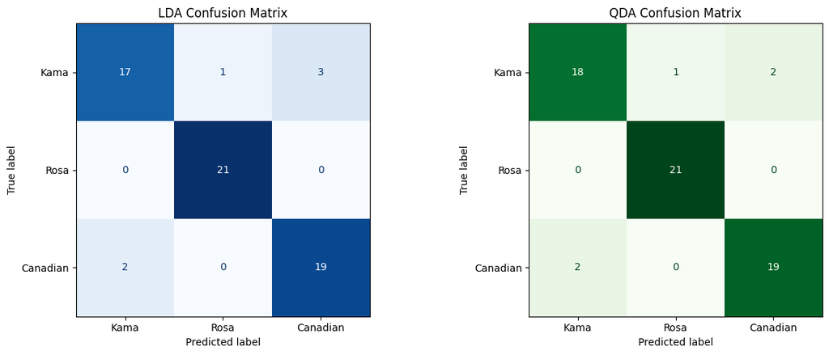

```python
fig, axes = plt.subplots(1, 2, figsize=(13, 5))

ConfusionMatrixDisplay(
    confusion_matrix=lda_cm,
    display_labels=class_order
).plot(ax=axes[0], cmap="Blues", colorbar=False, values_format="d")
axes[0].set_title("LDA Confusion Matrix")

ConfusionMatrixDisplay(
    confusion_matrix=qda_cm,
    display_labels=class_order
).plot(ax=axes[1], cmap="Greens", colorbar=False, values_format="d")
axes[1].set_title("QDA Confusion Matrix")

plt.tight_layout()
plt.show()
```

Initial interpretation of the confusion matrices

The held-out testing set contains 21 observations from each variety, for a total of 63 observations.

- LDA correctly classified 17 Kama, 21 Rosa, and 19 Canadian observations. Its six errors consisted of four Kama observations and two Canadian observations being assigned to another class.
- QDA correctly classified 18 Kama, 21 Rosa, and 19 Canadian observations. Its five errors consisted of three Kama observations and two Canadian observations being assigned to another class. Both models correctly classified all 21 Rosa observations. The difference between the two confusion matrices is one additional correctly classified Kama observation by QDA.

```python
def calculate_one_vs_rest_metrics(cm, labels, model_name):
    total = cm.sum()
    results = []

    for i, class_name in enumerate(labels):
        tp = cm[i, i]
        fn = cm[i, :].sum() - tp
        fp = cm[:, i].sum() - tp
        tn = total - tp - fn - fp

        sensitivity = tp / (tp + fn) if (tp + fn) > 0 else np.nan
        specificity = tn / (tn + fp) if (tn + fp) > 0 else np.nan

        results.append({
            "Model": model_name,
            "Wheat Variety": class_name,
            "TP": int(tp),
            "FN": int(fn),
            "FP": int(fp),
            "TN": int(tn),
            "Sensitivity": sensitivity,
            "Specificity": specificity
        })

    return pd.DataFrame(results)

lda_class_metrics = calculate_one_vs_rest_metrics(
    lda_cm, class_order, "LDA"
)
qda_class_metrics = calculate_one_vs_rest_metrics(
    qda_cm, class_order, "QDA"
)

class_metrics_comparison = pd.concat(
    [lda_class_metrics, qda_class_metrics],
    ignore_index=True
)

display(class_metrics_comparison.round(4))
```

|  | Model | Wheat Variety | TP | FN | FP | TN | Sensitivity | Specificity |
| --- | --- | --- | --- | --- | --- | --- | --- | --- |
| 0 | LDA | Kama | 17 | 4 | 2 | 40 | 0.8095 | 0.9524 |
| 1 | LDA | Rosa | 21 | 0 | 1 | 41 | 1.0000 | 0.9762 |
| 2 | LDA | Canadian | 19 | 2 | 3 | 39 | 0.9048 | 0.9286 |
| 3 | QDA | Kama | 18 | 3 | 2 | 40 | 0.8571 | 0.9524 |
| 4 | QDA | Rosa | 21 | 0 | 1 | 41 | 1.0000 | 0.9762 |
| 5 | QDA | Canadian | 19 | 2 | 2 | 40 | 0.9048 | 0.9524 |

Interpretation of class-wise sensitivity and specificity

The one-versus-rest measures provide a more detailed view than overall accuracy:

- Kama: LDA sensitivity is (17/21 = 0.8095), or 80.95%. QDA sensitivity is (18/21 = 0.8571), or 85.71%. QDA therefore identifies one more actual Kama observation correctly. Both models have a Kama specificity of 95.24%.
- Rosa: Both models have sensitivity of (21/21 = 1.0000), or 100%, because no actual Rosa observation was misclassified. Their specificity is (41/42 = 0.9762), or 97.62%.
- Canadian: Both models have sensitivity of (19/21 = 0.9048), or 90.48%. LDA specificity is (39/42 = 0.9286), or 92.86%, while QDA specificity is (40/42 = 0.9524), or 95.24%. The strongest class-level result for both classifiers is Rosa, which has perfect sensitivity on this testing partition. The weakest sensitivity is for Kama, particularly under LDA. This indicates that some Kama kernels are more difficult for the models to distinguish from the other varieties using the seven measurements.

Calculate Accuracy and Misclassification Rate

Overall accuracy is the proportion of testing observations correctly classified. It is calculated by dividing the sum of the diagonal entries of the confusion matrix by the total number of observations.

```python
def calculate_overall_metrics(cm, model_name):
    total = cm.sum()
    correct = np.trace(cm)
    incorrect = total - correct
    accuracy = correct / total
    misclassification_rate = incorrect / total

    return {
        "Model": model_name,
        "Correct Predictions": int(correct),
        "Incorrect Predictions": int(incorrect),
        "Testing Observations": int(total),
        "Accuracy": accuracy,
        "Misclassification Rate": misclassification_rate
    }

test_metrics = pd.DataFrame([
    calculate_overall_metrics(lda_cm, "LDA"),
    calculate_overall_metrics(qda_cm, "QDA")
])

display(test_metrics.round(4))
```

|  | Model | Correct Predictions | Incorrect Predictions | Testing Observations | Accuracy | Misclassification Rate |
| --- | --- | --- | --- | --- | --- | --- |
| 0 | LDA | 57 | 6 | 63 | 0.9048 | 0.0952 |
| 1 | QDA | 58 | 5 | 63 | 0.9206 | 0.0794 |

On this particular testing set, QDA has a higher accuracy than LDA by approximately 1.59 percentage points. This difference corresponds to only one additional correctly classified observation out of 63. Thus, the test-set accuracy alone provides only a small observed advantage for QDA.

Perform Stratified Five-Fold Cross-Validation

To further assess predictive performance, stratified five-fold cross-validation is applied to the training set only. The testing set remains untouched during this validation procedure.

The 147 training observations are divided into five folds. In each iteration, four folds are used to fit the classifier and the remaining fold is used for validation. Each observation in the training set is used for validation once.

A higher mean indicates stronger average validation accuracy, while a lower standard deviation indicates less variation in accuracy across the five folds. The same stratified folds are used for LDA and QDA to make the comparison consistent.

```python
# Generate the same five stratified folds for both algorithms.
cv = StratifiedKFold(
    n_splits=5,
    shuffle=True,
    random_state=42
)

# Explicitly store the fold indices so both models use identical partitions.
cv_splits = list(cv.split(X_train, y_train))

lda_cv_scores = cross_val_score(
    LinearDiscriminantAnalysis(),
    X_train,
    y_train,
    cv=cv_splits,
    scoring="accuracy"
)

qda_cv_scores = cross_val_score(
    QuadraticDiscriminantAnalysis(reg_param=0.0001),
    X_train,
    y_train,
    cv=cv_splits,
    scoring="accuracy"
)

cv_fold_results = pd.DataFrame({
    "Fold": [1, 2, 3, 4, 5],
    "LDA Accuracy": lda_cv_scores,
    "QDA Accuracy": qda_cv_scores
})

display(cv_fold_results.round(4))
```

|  | Fold | LDA Accuracy | QDA Accuracy |
| --- | --- | --- | --- |
| 0 | 1 | 0.9667 | 0.9333 |
| 1 | 2 | 1.0000 | 1.0000 |
| 2 | 3 | 1.0000 | 0.9310 |
| 3 | 4 | 0.9655 | 1.0000 |
| 4 | 5 | 1.0000 | 0.9655 |

```python
cv_summary = pd.DataFrame({
    "Model": ["LDA", "QDA"],
    "Mean CV Accuracy": [
        lda_cv_scores.mean(),
        qda_cv_scores.mean()
    ],
    "SD of CV Accuracy": [
        lda_cv_scores.std(ddof=1),
        qda_cv_scores.std(ddof=1)
    ]
})

cv_summary["Mean CV Accuracy (%)"] = (
    cv_summary["Mean CV Accuracy"] * 100
)
cv_summary["SD of CV Accuracy (percentage points)"] = (
    cv_summary["SD of CV Accuracy"] * 100
)

display(cv_summary.round(4))
```

|  | Model | Mean CV Accuracy | SD of CV Accuracy | Mean CV Accuracy (%) | SD of CV Accuracy (percentage points) |
| --- | --- | --- | --- | --- | --- |
| 0 | LDA | 0.9864 | 0.0186 | 98.6437 | 1.8577 |
| 1 | QDA | 0.9660 | 0.0339 | 96.5977 | 3.3919 |

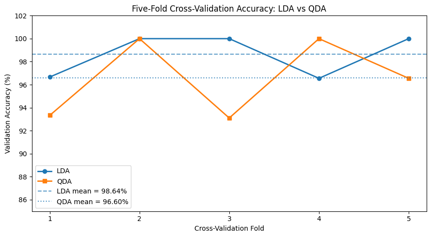

```python
fold_numbers = np.arange(1, 6)

plt.figure(figsize=(9, 5))
plt.plot(
    fold_numbers, lda_cv_scores * 100,
    marker="o", linewidth=2, label="LDA"
)
plt.plot(
    fold_numbers, qda_cv_scores * 100,
    marker="s", linewidth=2, label="QDA"
)

plt.axhline(
    lda_cv_scores.mean() * 100,
    linestyle="--",
    alpha=0.7,
    label=f"LDA mean = {lda_cv_scores.mean()*100:.2f}%"
)
plt.axhline(
    qda_cv_scores.mean() * 100,
    linestyle=":",
    alpha=0.8,
    label=f"QDA mean = {qda_cv_scores.mean()*100:.2f}%"
)

plt.xticks(fold_numbers)
plt.ylim(85, 102)
plt.xlabel("Cross-Validation Fold")
plt.ylabel("Validation Accuracy (%)")
plt.title("Five-Fold Cross-Validation Accuracy: LDA vs QDA")
plt.legend()
plt.tight_layout()
plt.show()
```

LDA obtained a mean cross-validation accuracy of approximately 98.64%, compared with 96.60% for QDA. The mean validation accuracy of LDA is therefore higher by approximately 2.05 percentage points.

LDA also has a smaller fold-to-fold standard deviation (1.86 percentage points) than QDA (3.39 percentage points). This indicates that LDA's accuracy was more consistent across the five validation folds in this analysis.

The cross-validation results favor LDA, even though QDA performed slightly better on the single held-out testing set. This difference highlights why model selection should not rely on one test-set accuracy value alone.

Overall Model Comparison and Decision

The test-set results and cross-validation results provide two complementary assessments:

- The held-out testing set evaluates each model on 63 observations excluded from the model-fitting process. QDA correctly classified 58 observations, while LDA correctly classified 57.
- The five-fold cross-validation evaluates repeated train-validation partitions within the 147-observation training set. LDA achieved the higher mean validation accuracy and the smaller fold-to-fold standard deviation.

```python
# Combine held-out test metrics and cross-validation summaries.
final_comparison = test_metrics.merge(
    cv_summary[
        ["Model", "Mean CV Accuracy", "SD of CV Accuracy"]
    ],
    on="Model"
)

final_comparison["Test Accuracy (%)"] = (
    final_comparison["Accuracy"] * 100
)
final_comparison["Test Error Rate (%)"] = (
    final_comparison["Misclassification Rate"] * 100
)
final_comparison["Mean CV Accuracy (%)"] = (
    final_comparison["Mean CV Accuracy"] * 100
)
final_comparison["CV SD (percentage points)"] = (
    final_comparison["SD of CV Accuracy"] * 100
)

display(final_comparison[
    [
        "Model",
        "Correct Predictions",
        "Incorrect Predictions",
        "Test Accuracy (%)",
        "Test Error Rate (%)",
        "Mean CV Accuracy (%)",
        "CV SD (percentage points)"
    ]
].round(4))
```

|  | Model | Correct Predictions | Incorrect Predictions | Test Accuracy (%) | Test Error Rate (%) | Mean CV Accuracy (%) | CV SD (percentage points) |
| --- | --- | --- | --- | --- | --- | --- | --- |
| 0 | LDA | 57 | 6 | 90.4762 | 9.5238 | 98.6437 | 1.8577 |
| 1 | QDA | 58 | 5 | 92.0635 | 7.9365 | 96.5977 | 3.3919 |

Statistical decision and interpretation

Based on the results, LDA is the preferred model according to the cross-validation results, while QDA has a marginally higher accuracy on the single held-out testing set.

Although QDA achieved 92.06% test accuracy compared with LDA's 90.48%, its advantage represents only one additional correctly classified observation. In contrast, LDA achieved a higher mean five-fold validation accuracy (98.64% versus 96.60%) and showed lower variation across folds (1.86 versus 3.39 percentage points).

The difference in performance can be related to the models' covariance estimation:

- LDA estimates one pooled covariance matrix across the three classes. This reduces the number of covariance parameters and can produce more stable estimates when the training sample is limited.
- QDA estimates a separate covariance matrix for each class. This provides flexibility when class covariance structures differ, as suggested by Box's M-test, but it also increases the number of parameters that must be estimated. With only 147 training observations divided across three varieties, these estimates may be more variable. Therefore, the empirical findings show that the model that better accommodates the covariance structure theoretically does not necessarily achieve the highest validation accuracy. The observed cross-validation results favor the simpler LDA model for this dataset and partition, while the held-out test results show that QDA remains a competitive alternative.

The difference between the models is small, and the conclusion should not be interpreted as proof that LDA will always outperform QDA on other wheat samples.

## Geometrical Characteristics That Contribute to Distinguishing the Wheat Varieties

The ability to distinguish the three wheat varieties is primarily associated with differences in their geometrical measurements, particularly area, perimeter, kernel width, kernel groove length, and kernel length.

To examine these differences, the mean of each numerical predictor was compared across the three varieties. Additionally, a one-way ANOVA was used to evaluate whether the population means of each measurement differ significantly among the varieties.

The one-way ANOVA tests the following hypotheses for each numerical characteristic:

**Null Hypothesis ($H_0$):** The mean measurement is equal across the three wheat varieties.

**Alternative Hypothesis ($H_1$):** At least one wheat variety has a different mean measurement.

The results are summarized below:

| Geometrical Characteristic | F-statistic | p-value | Eta-squared ($\eta^2$) |
| --- | --- | --- | --- |
| Area | 548.19 | $1.96 \times 10^{-83}$ | 0.8412 |
| Perimeter | 541.58 | $5.64 \times 10^{-83}$ | 0.8396 |
| Kernel Width | 406.30 | $2.14 \times 10^{-72}$ | 0.7970 |
| Kernel Groove Length | 368.95 | $5.63 \times 10^{-69}$ | 0.7809 |
| Kernel Length | 322.19 | $2.73 \times 10^{-64}$ | 0.7569 |
| Compactness | 75.87 | $1.92 \times 10^{-25}$ | 0.4230 |
| Asymmetry Coefficient | 51.89 | $5.43 \times 10^{-19}$ | 0.3339 |

All seven characteristics exhibit statistically significant differences among the three wheat varieties at the 0.05 significance level.

The effect size, measured using eta-squared, provides additional information regarding the proportion of the total variation in each measurement associated with differences between wheat varieties. It is calculated as:

$$ \eta^2 = \frac{SS_{\text{Between}}}{SS_{\text{Total}}} $$

For example, the area measurement has an eta-squared value of 0.8412, indicating that approximately 84.12% of its observed variation is associated with differences between the wheat varieties in this sample.

Based on these results, area and perimeter demonstrate the strongest individual separation among the varieties, followed by kernel width, kernel groove length, and kernel length.

The class means further illustrate these differences. Rosa generally exhibits the largest kernel dimensions, with a mean area of 18.3343 and a mean perimeter of 16.1357. Canadian exhibits the smallest mean area of 11.8739 and perimeter of 13.2479. Kama generally occupies an intermediate position, with a mean area of 14.3344 and perimeter of 14.2943.

Meanwhile, the asymmetry coefficient provides another distinguishing characteristic. Canadian has the highest mean asymmetry coefficient of 4.7884, compared with 3.6448 for Rosa and 2.6674 for Kama.

These findings suggest that wheat varieties can be distinguished using a combination of kernel size, shape, and structural measurements rather than relying on a single geometrical characteristic.

However, the ANOVA results represent individual, univariate comparisons. Since some geometrical measurements may be correlated, their individual effect sizes should not be interpreted as independent contributions to multivariate classification.

## Differences Between LDA and QDA Classification Boundaries

Linear Discriminant Analysis (LDA) and Quadratic Discriminant Analysis (QDA) differ primarily in how they estimate and utilize the covariance structure of each wheat variety.

LDA assumes that the three varieties share a common covariance matrix:

$$ \Sigma_1 = \Sigma_2 = \Sigma_3 = \Sigma $$

Under this assumption, LDA estimates a pooled covariance matrix and determines the discriminant function using the class mean vectors, covariance structure, and prior probabilities.

Its discriminant function can be expressed as:

$$ \delta_k(\mathbf{x}) = \mathbf{x}^T\Sigma^{-1}\boldsymbol{\mu}_k -\frac{1}{2}\boldsymbol{\mu}_k^T \Sigma^{-1}\boldsymbol{\mu}_k +\ln(\pi_k) $$

Where:

- $\mathbf{x}$ represents the seven-dimensional observation vector.
- $\boldsymbol{\mu}_k$ represents the mean vector of class $k$.
- $\Sigma$ represents the common covariance matrix.
- $\pi_k$ represents the prior probability of class $k$.

Since the covariance matrix is shared across all classes, the quadratic terms cancel when comparing two discriminant functions. Consequently, the resulting classification boundaries are linear hyperplanes in the predictor space.

In contrast, QDA does not require equal covariance matrices. Instead, it estimates a separate covariance matrix for every wheat variety:

$$ \Sigma_k \text{ is estimated separately for each class} $$

Its discriminant function is:

$$ \delta_k(\mathbf{x}) = -\frac{1}{2}\ln|\Sigma_k| -\frac{1}{2} (\mathbf{x}-\boldsymbol{\mu}_k)^T \Sigma_k^{-1} (\mathbf{x}-\boldsymbol{\mu}_k) +\ln(\pi_k) $$

Because each class has its own covariance matrix, the quadratic terms do not cancel when comparing classes. This produces quadratic classification boundaries that may be curved.

Therefore, LDA provides a simpler classification structure, while QDA offers greater flexibility in representing differences in the covariance structures of the three varieties.

In the context of this analysis, QDA can potentially represent the different variability and relationships among kernel measurements more effectively. However, its greater flexibility also requires estimating more parameters, which can increase estimation uncertainty when the training sample is limited.

## Interpretation of Box's M-Test and Covariance Structures

Box's M-test was conducted to determine whether the covariance matrices of the three wheat varieties are statistically equal.

The hypotheses were:

**Null Hypothesis ($H_0$):**

The covariance matrices of all three varieties are equal.

$$ H_0: \Sigma_{\text{Kama}} = \Sigma_{\text{Rosa}} = \Sigma_{\text{Canadian}} $$

**Alternative Hypothesis ($H_1$):**

At least one pair of covariance matrices differs.

$$ H_1: \Sigma_i \neq \Sigma_j \quad \text{for at least one pair } i \neq j $$

The test produced the following results:

- Corrected chi-square statistic: 674.1173
- Degrees of freedom: 56
- p-value: $7.3196 \times 10^{-107}$

Since the p-value is substantially smaller than the significance level of 0.05, the null hypothesis is rejected.

This provides strong statistical evidence that the covariance matrices are not equal across the three wheat varieties.

In statistical terms, the varieties do not necessarily share the same pattern of variability and relationships among their seven geometrical measurements.

This finding is particularly relevant to discriminant analysis because LDA assumes a common covariance structure, whereas QDA allows each variety to have its own covariance matrix.

Therefore, based on the covariance assumption alone, QDA is theoretically more appropriate for accommodating the observed differences.

Nevertheless, Box's M-test is sensitive to departures from multivariate normality. Since the earlier Henze–Zirkler tests identified departures from multivariate normality in Kama and Rosa, the result should be interpreted with caution.

## Consistency Between Empirical Performance and Theoretical Assumptions

The empirical classification results demonstrate that theoretical assumptions and actual predictive performance do not necessarily lead to the same model preference.

The Henze–Zirkler test indicated that multivariate normality was not fully satisfied across the three varieties. Specifically, Kama and Rosa had p-values below 0.05, while Canadian had a p-value of 0.1448.

Furthermore, Box's M-test rejected the assumption of equal covariance matrices. These findings indicate that the theoretical assumptions of LDA are not fully supported by the observed dataset.

QDA is more consistent with the unequal covariance finding because it estimates separate covariance matrices for each class. However, both LDA and QDA are theoretically derived under class-conditional multivariate normality assumptions. Therefore, neither model completely satisfies all of its theoretical assumptions.

Despite this, both classifiers achieved relatively high predictive performance.

On the independent testing set, LDA obtained an accuracy of 90.48%, while QDA obtained 92.06%. QDA therefore performed slightly better on this particular testing partition.

However, the five-fold cross-validation results showed a different outcome. LDA achieved a mean validation accuracy of 98.64%, compared with 96.60% for QDA. Additionally, LDA demonstrated lower fold-to-fold variation, with a standard deviation of 1.86 percentage points compared with 3.39 percentage points for QDA.

This suggests that although QDA is more flexible in representing unequal covariance structures, LDA provided more consistent validation performance in this analysis.

The difference may be related to model complexity. QDA estimates separate covariance matrices for each class, requiring more parameters than LDA. With a relatively small training sample of 147 observations, these additional estimates may introduce greater variability.

Therefore, the empirical findings are partially consistent with the theoretical expectations. QDA better accommodates unequal covariance structures, but LDA demonstrates stronger average cross-validation performance.

It is important to recognize that statistical assumptions describe the theoretical conditions under which the discriminant methods are derived. Their predictive performance must still be assessed using appropriate validation procedures.

## Recommended Classification Model

Based on the overall evaluation, Linear Discriminant Analysis (LDA) is recommended as the preferred classification model for identifying the three wheat varieties in this analysis.

Although QDA achieved a slightly higher testing accuracy of 92.06%, compared with 90.48% for LDA, the difference represents only one additional correctly classified observation out of 63 testing observations.

More importantly, LDA achieved a higher mean five-fold cross-validation accuracy of 98.64%, compared with 96.60% for QDA. LDA also demonstrated lower variation across the validation folds, indicating more consistent predictive performance within the training data.

The recommendation is therefore based on validation performance rather than relying exclusively on the highest observed testing accuracy.

Furthermore, LDA has a simpler covariance estimation structure. It estimates a pooled covariance matrix instead of separate covariance matrices for each variety, reducing the number of parameters that must be estimated.

This can be advantageous when working with a relatively limited sample size, particularly when the predictor variables contain correlated measurements.

Nevertheless, this recommendation should be considered specific to the present dataset and validation procedure. The unequal covariance structures identified by Box's M-test indicate that QDA remains a theoretically relevant alternative and may perform better under different samples or validation partitions.

## Limitations of the Analysis

Despite the relatively high classification performance, several limitations should be considered when interpreting the findings.

First, the dataset contains only 210 observations, with 70 observations per wheat variety. Although the classes are balanced, the sample size remains relatively small for estimating seven-dimensional covariance structures, particularly for QDA.

Second, the classification evaluation used a single stratified 70:30 training-testing partition. Although five-fold cross-validation was performed on the training set, the results may still vary under different random partitions. Repeated stratified cross-validation or additional independent observations could provide stronger evidence of generalization performance.

Third, the multivariate normality assumption was not fully satisfied. This may affect the theoretical justification of both discriminant methods, while also requiring caution when interpreting Box's M-test.

Fourth, several observations were identified as potential outliers through the IQR method. These were retained because they may represent natural differences in kernel geometry rather than measurement errors. Nevertheless, extreme observations may influence the estimation of class means and covariance matrices.

Fifth, the geometrical measurements may contain substantial correlations. For example, area and perimeter describe related aspects of kernel size. Consequently, the individual contribution of each variable cannot be interpreted independently based solely on univariate statistical comparisons.

Finally, the analysis is limited to the prescribed UCI Seeds Dataset. High classification accuracy on these observations does not automatically guarantee equivalent performance on wheat samples collected from other environments, growing conditions, or measurement procedures.

## Conclusion

The findings demonstrate that the three wheat varieties can be distinguished effectively using their seven geometrical characteristics. Area, perimeter, kernel width, kernel groove length, and kernel length exhibit particularly strong differences among the varieties.

The assumption tests revealed departures from multivariate normality in Kama and Rosa, as well as statistically significant differences in covariance matrices across the three varieties. These findings theoretically favor considering QDA because of its ability to accommodate class-specific covariance structures.

However, predictive evaluation produced a more nuanced result. QDA obtained slightly higher accuracy on the independent testing set, while LDA achieved higher mean cross-validation accuracy and more consistent validation performance.